# PA1Template

This is the first Peer Assesment for Reproducible Data. In this analysis we will be studying the number of steps taken by an individual in October and November of 2012

Load needed libraries

```r
library(plyr)
```

Load the step data

```r
setwd("/Users/rolandjacobus/Desktop/Coursera/Coursera - Reproducible Data/PA1")
steps<-read.csv("activity-4.csv")
```

Process the Data by changing dates to date class and removing rows with NAs

```r
Steps<-data.frame(steps$steps,as.Date(steps$date),steps$interval)
names(Steps)<-c("steps","date","interval")
cleanSteps<-Steps[complete.cases(Steps),]
names(cleanSteps)<-c("steps","date","interval")
```

Sum the total number of steps taken each day and make a histogram

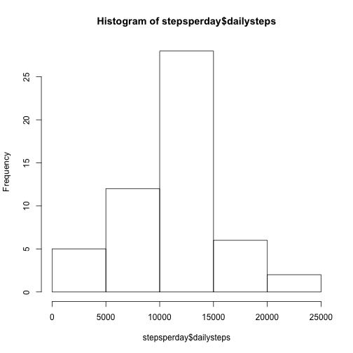

```r
stepsperday<-ddply(cleanSteps,c("date"),summarize, dailysteps=sum(steps))
hist(stepsperday$dailysteps)
```

Calculate and report the mean and median total number of steps taken each day

```r
mean(stepsperday$dailysteps)
```

```
## [1] 10766
```

```r
median(stepsperday$dailysteps)
```

```
## [1] 10765
```

Make a time series x = 5 minute and y= average across all days

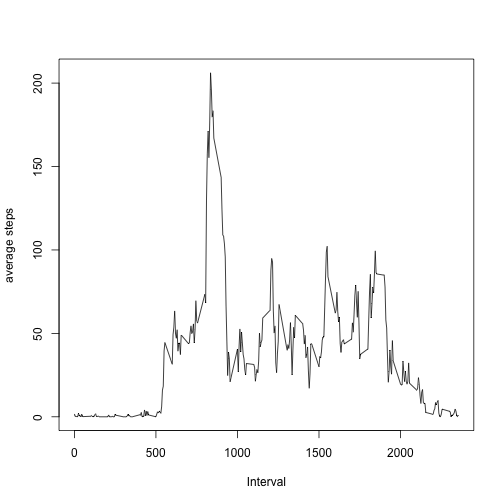

```r
intervalmean<-aggregate(steps~interval,cleanSteps,mean)
plot(intervalmean$interval,intervalmean$steps,type="l",xlab="Interval", ylab="average steps")
```

```r
max(intervalmean$steps)
```

```
## [1] 206.2
```

Caclulate and report the total the total number of rows with NAs

```r
nrow(Steps)-nrow(cleanSteps)
```

```
## [1] 2304
```

Replace NAs with mean the mean steps and create a new dataset …a very simple replacement process.

```r
NewSteps<-Steps
NewSteps[is.na(NewSteps)]<- 37.38
```

Make a histogram of the total number of steps taken each day.

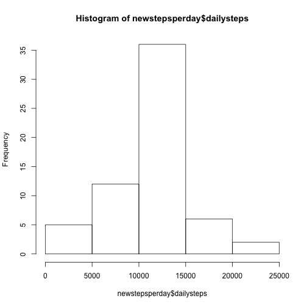

```r
newstepsperday<-ddply(NewSteps,c("date"),summarize, dailysteps=sum(steps))
hist(newstepsperday$dailysteps)
```

Calculate and report the mean and median total steps taken each day

```r
mean(newstepsperday$dailysteps)
```

```
## [1] 10766
```

```r
median(newstepsperday$dailysteps)
```

```
## [1] 10765
```

```r
NewSteps$day<-weekdays(as.Date(NewSteps$date))
```

[figure not shown]

```r
avgSteps<-ddply(NewSteps,c("day","interval"),summarize, mean(NewSteps$steps))
plot(avgSteps$interval,avgSteps$steps,type="l",xlab="Interval", ylab="average steps")
```